# fise_solarDaylight

## Contents

- Solar radiation, Fraunhofer lines, Earth lines, Daylight basis
- Solar radiation and Fraunhofer lines
- Sample measurements
- The Judd Macadam Wyszecki Daylight model
- Stanford sunlight
- Properties of the weights

## Solar radiation, Fraunhofer lines, Earth lines, Daylight basis

#sec-lightfield-properties

The solar radiation has a fairly stable spectrum, with lines that represent where atoms in the surface of the sun absorb (Fraunhofer). As the radiation reaches the surface of the earth, it is also absorbed and scattered by particles and water in the atmosphere. Finally, the length of the trip through the atmosphere depends on the time of day, as the Earth rotates.

These graphs illustrate some of the standards of solar radiation, including a model of the skylight illumination at the Earth's surface.

```matlab
%{
imgdir = '~/Documents/FISE-git/chapters/images/lightfields';
fise_plotDefaults;
exportPlots = true;
%}
exportPlots = false;
```

## Solar radiation and Fraunhofer lines

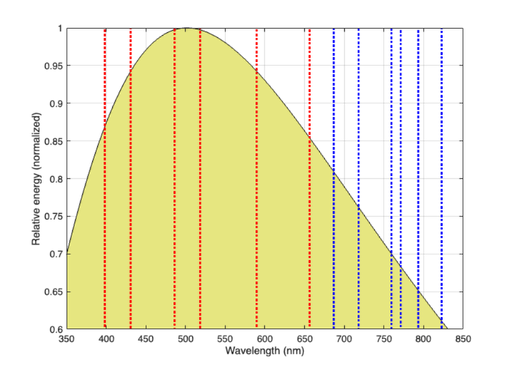

```matlab
wave = 280:830;
[solar,~,comment] = ieReadSpectra('solarSpectrum',wave);

hFig = ieFigure;
area(wave,solar,'FaceColor',[0.9 0.9 .5]); hold on;
plot(wave,solar,'k-');hold on;

% Now some of the lines
allLines = comment{4};

% These are some examples for plotting.
fSelectSolar = comment{5};
fSelectEarth = comment{6};

solarLines = allLines(fSelectSolar(:),:);
solarLines = cell2mat(solarLines(:,3))';

earthLines = allLines(fSelectEarth(:),:);
earthLines = cell2mat(earthLines(:,3))';

ylim = get(gca,'ylim');
x = earthLines;
for ii=1:numel(x)
    % line([x(ii),x(ii)],[ylim(1),ylim(1)+0.1],'Color','b');
    line([x(ii),x(ii)],[ylim(1),1],'Color','b',...
        'linestyle',':',...
        'LineWidth',2);
end

x = solarLines;
for ii=1:numel(x)
    % line([x(ii),x(ii)],[ylim(1),ylim(1)+0.1],'Color','r');
    line([x(ii),x(ii)],[ylim(1),1],'Color','r',...
        'linestyle',':',...
        'LineWidth',2);
end
set(gca,'xlim',[350 850]);
set(gca,'ylim',[0.6 1]);

grid on;
xlabel('Wavelength (nm)'); ylabel('Relative energy (normalized)');

if exportPlots
    exportgraphics(gca,fullfile(imgdir,'01-solar-lines.png'),...
        'Resolution',150); %#ok<*UNRCH>
end
```

## Sample measurements

Daylights from the [Granada color image](https://colorimaginglab.ugr.es/pages/data#__doku_granada_skylight_spectral_database) lab database

Peyvandi, Shahram, Javier Hernández-Andrés, F. J. Olmo, Juan Luis Nieves, and Javier Romero. 2016. “Colorimetric Analysis of Outdoor Illumination across Varieties of Atmospheric Conditions.” *Journal of the Optical Society of America. A, Optics, Image Science, and Vision* 33 (6): 1049–59.

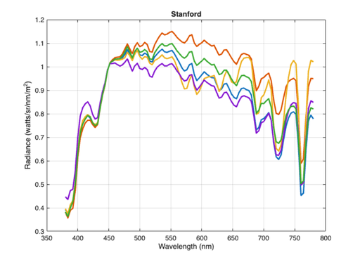

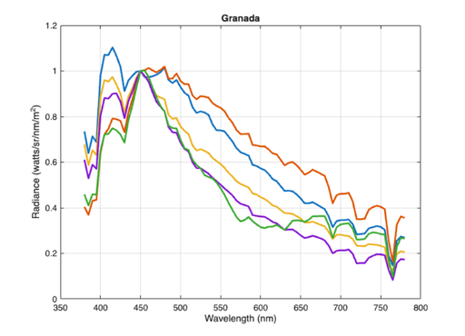

```matlab
wave = 380:780;

% Should we have a normalized wave option for this method?
stanford = ieReadSpectra('daylightStanford',wave);
granada  = ieReadSpectra('daylightGranada',wave);
for ii=1:size(stanford,2)
    stanford(:,ii) = stanford(:,ii)/stanford(wave==450,ii);
end
for ii=1:size(stanford,2)
    granada(:,ii) = granada(:,ii)/granada(wave==450,ii);
end
% idx = randi(size(stanford,2),[1,5]);
idx = [54   527   208   133   222];
plotRadiance(wave,stanford(:,idx));
set(gca,'userdata',idx);
title('Stanford')
% idx = get(hdl1,'userdata')

% idx = randi(size(granada,2),[1,5]);
idx = [230   297    67   996   442];
plotRadiance(wave,granada(:,idx));
set(gca,'userdata',idx);
title('Granada')
% idx = get(hdl2,'userdata')

if exportPlots
    hdl = ieFigure([],'wide');
    tiledlayout(1,2);
    nexttile;
    plotRadiance(wave,stanford(:,idx),'hdl',hdl);
    ylabel('Normalized radiance (re:450)')
    title('Stanford')
    nexttile;
    plotRadiance(wave,granada(:,idx),'hdl',hdl);
    title('Granada')
    ylabel('Normalized radiance (re:450)')
    set(gcf,'Position',[0.0133    0.5188    0.5223    0.3882]);
    A = findobj(gcf,'Type','axes');
    set(A(1),'ylim',[0,1.3],'FontSize',16);
    set(A(2),'ylim',[0,1.3],'FontSize',16);
    exportgraphics(gcf,fullfile(imgdir,'01-solar-samples.png'),...
        'Resolution',150);
end
```

## The Judd Macadam Wyszecki Daylight model

This group and several others measured the spectral distributions of irradiance at the Earth's surface. The found a two-dimensional linear model that described a large percentage of the variance of their (normalized) data (mean plus two basis vectors). These have been confirmed by other authors, and here is the models that has been adopted as a CIE standard.

This plot shows the three functions along with a circle at several of the Fraunhofer lines. You can see how the small discontinuities in the mean at most of these lines.

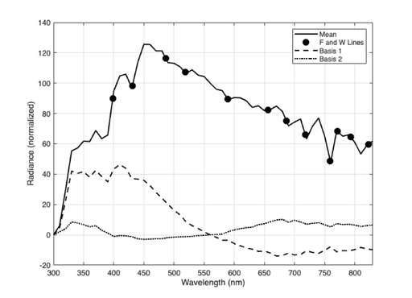

```matlab
[dayBasis,wave] = ieReadSpectra('cieDaylightBasis');

ieFigure;
sym = {'k-','k--','k:'};
for ii=1:3
    plot(wave,dayBasis(:,ii),sym{ii},'LineWidth',1.5); hold on;
    if ii==1
        tmp = interp1(wave,dayBasis(:,ii),[earthLines, solarLines]);
        plot([earthLines, solarLines],tmp,'ko',...
            'MarkerSize',8,'MarkerFaceColor','k');
    end
end
grid on;
set(gca,'xlim',[300 830]);
legend({'Mean','F and W Lines','Basis 1','Basis 2'});
xlabel('Wavelength (nm)'); ylabel('Radiance (normalized)');

if exportPlots
    exportgraphics(gca,fullfile(imgdir,'01-solar-basis.png'),...
        'Resolution',150);
end
```

## Stanford sunlight

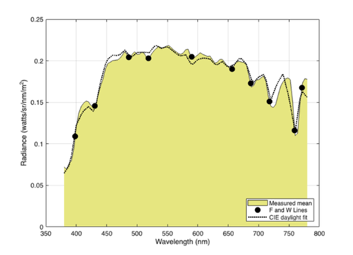

```matlab
[spd,wave] = ieReadSpectra('daylightStanford');
spdM = mean(spd,2);

ieFigure;
% plot(wave,spdM,'k-','LineWidth',1.5); hold on;
hA = area(wave,spdM,'FaceColor',[0.9 0.9 0.5]); hold on;

% {
tmp = interp1(wave,spdM,[earthLines, solarLines]);
hB = plot([earthLines, solarLines],tmp,'ko',...
    'MarkerSize',8,...
    'MarkerFaceColor','k');
%}

dayBasis = ieReadSpectra('cieDaylightBasis',wave);
wgts = pinv(dayBasis)*spdM;
pred = dayBasis*wgts;
hC = plot(wave,pred,'k:','LineWidth',1.5);

grid on;
set(gca,'xlim',[350 800]);
xlabel('Wavelength (nm)'); ylabel('Radiance (watts/sr/nm/m^2)');
legend([hA,hB,hC],{'Measured mean','F and W Lines','CIE daylight fit'},'location','southeast');

if exportPlots
    exportgraphics(gca,fullfile(imgdir,'01-solar-stanford.png'),...
        'Resolution',150);
end
```

## Properties of the weights

The basis functions are guaranteed to be perpendicular to one another. But the weights are not statistically indepdent. Let's have a look (DiCarlo article makes this point. Double check it).

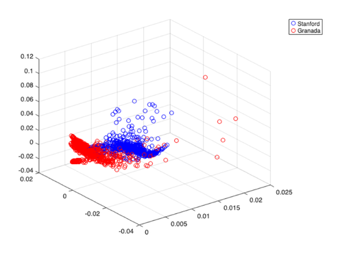

```matlab
spd = cat(2,stanford,granada);
sNum = size(stanford,2);
wave = 380:780;
dayBasis = ieReadSpectra('cieDaylightBasis',wave);
wgts = pinv(dayBasis)*spd;
% size(wgts)

hdl = ieFigure;
scatter3(wgts(1,1:sNum),wgts(2,1:sNum),wgts(3,1:sNum),'bo'); hold on;
scatter3(wgts(1,sNum+1:end),wgts(2,sNum+1:end),wgts(3,sNum+1:end),'ro'); hold on;
legend({'Stanford','Granada'})
grid on;

if exportPlots
    fname = fullfile(imgdir,'01-dayweights3d.gif');
    azSteps = [0:3:90 80:-3:10];
    gif_filename = ie3dGIF(hdl,'file name',fname,...
        'azimuth steps',azSteps,...
        'delay time',0.15, ...
        'elevation',25);
end
```

[Published with MATLAB® R2026a](https://www.mathworks.com/products/matlab/)